# HW3 Cheat Sheet

This is a cheat sheet for the third homework. It works through each step in R.

First, you need the following packages.

```r
library(igraph)
library(readr)
library(RColorBrewer)
```

## 1. Toy Graph

First, we are going to construct the toy graph. We can make an edge list based on how the nodes are connected to one another.

And make a vector of node colors that correspond to each of the nodes.

```r
edges <- c(1,2, 1,3, 1,6, 2,3, 2,5, 3,4, 3,5, 6,2)


colors <- c("yellow", "red", "green", "yellow", "red", "green")
```

Now we can use the graph function in igraph to read the graph into an igraph object and assign the color in the function.

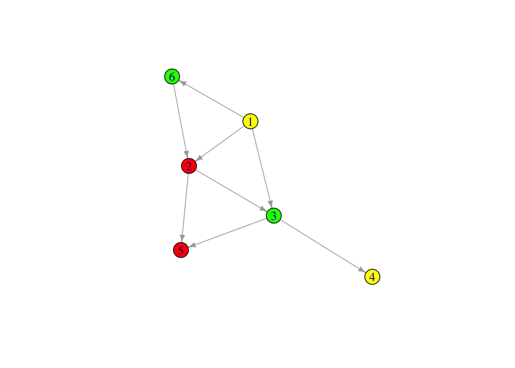

This is the HW03 Toy Graph

```r
t.g <- graph(edges, directed=T)

plot(t.g, vertex.color=colors, edge.arrow.size=.5)
```

You could also assign colors as vertex attribute in the igraph object. Then you don’t have to. assign colors inside the graph function.

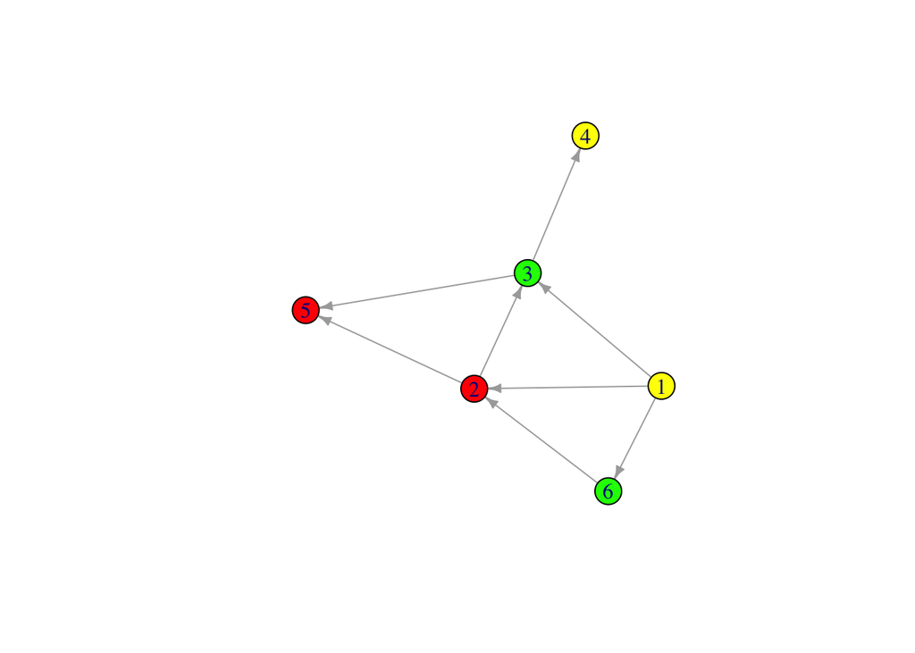

This is also the HW03 Toy Graph

```r
V(t.g)$color <- colors

plot(t.g, edge.arrow.size=.5)
```

## 2. Game of Thrones

First we load the data from the Game of Thrones book and inspect.

```r
stormofswords <- read_csv("data/stormofswords.csv")

head(stormofswords)
```

```
# A tibble: 6 × 3
  Source Target  Weight
  <chr>  <chr>    <dbl>
1 Aemon  Grenn        5
2 Aemon  Samwell     31
3 Aerys  Jaime       18
4 Aerys  Robert       6
5 Aerys  Tyrion       5
6 Aerys  Tywin        8
```

We can see that this is a weighted edgelist in a data frame. So, we can use graph_from_data_frame to make an igraph object. If we return the graph name, we can see the graph summary. We can also see an initial plot.

```r
thr.g <- graph_from_data_frame(stormofswords)

#Let's take a peek at the graph summary

thr.g
```

```
IGRAPH db58165 DN-- 107 352 --
+ attr: name (v/c), Weight (e/n)
+ edges from db58165 (vertex names):
 [1] Aemon  ->Grenn     Aemon  ->Samwell   Aerys  ->Jaime     Aerys  ->Robert
 [5] Aerys  ->Tyrion    Aerys  ->Tywin     Alliser->Mance     Amory  ->Oberyn
 [9] Arya   ->Anguy     Arya   ->Beric     Arya   ->Bran      Arya   ->Brynden
[13] Arya   ->Cersei    Arya   ->Gendry    Arya   ->Gregor    Arya   ->Jaime
[17] Arya   ->Joffrey   Arya   ->Jon       Arya   ->Rickon    Arya   ->Robert
[21] Arya   ->Roose     Arya   ->Sandor    Arya   ->Thoros    Arya   ->Tyrion
[25] Balon  ->Loras     Belwas ->Barristan Belwas ->Illyrio   Beric  ->Anguy
[29] Beric  ->Gendry    Beric  ->Thoros    Bran   ->Hodor     Bran   ->Jojen
+ ... omitted several edges
```

[figure not shown]

```r
#Initial plot

plot(thr.g)
```

The plot is a bit messy and it is hard to make much sense of it, so let’s add some additional information.

We can add the houses as attributes

```r
load("~/Documents/GitHub/sna_course/week_3_visualization/week3_visualization/data/got_att.rda") #This point to where attribute file is located

#Inspect thing

head(got_att)
```

```
    names degree house
1   Aemon      5     0
2   Aerys      4     0
3 Alliser      3     0
4   Amory      1     0
5    Arya     19     2
6   Balon      6     0
```

We can see there are names, degree, and the house (0=“Other”, 1=“Lannister”, 2=“Stark”, 3=“Tagaryen”, 4=“Baratheon”)

Let’s store those in the vertices

And plot with the setting vertex color by house and vertex size by degree, and edge width by weight

[figure not shown]

```r
V(thr.g)$degree <- got_att$degree

V(thr.g)$house <- got_att$house

plot(thr.g, vertex.color=V(thr.g)$house+1, vertex.size=V(thr.g)$degree/2, edge.arrow.size=.1, edge.width=E(thr.g)$Weight/10,
     layout=layout_with_kk)
```

It might be nice to include a legend. The Moody and Light 2020 tutorial describes how to accomplish that.

Start with the RColorBrewer Package and index the colors. Then connect the colors to the house attribute as a factor and plot.

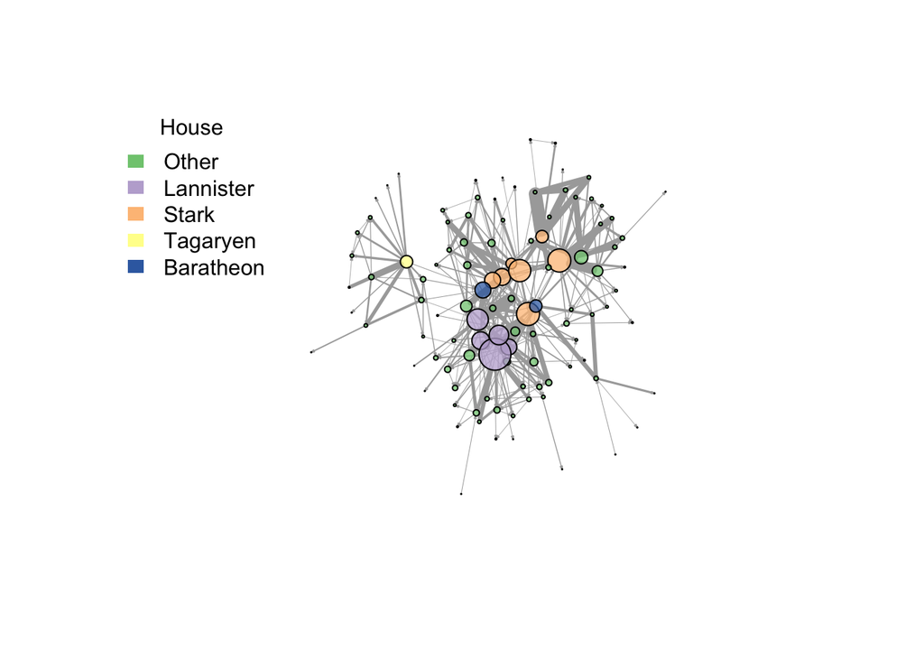

```r
library(RColorBrewer)

#Index the colors

pal <- brewer.pal(5, "Accent")

#Connect the colors to the house attribte as a factor

vertex.col <- (pal[as.numeric(as.factor(vertex_attr(thr.g, "house")))])

#plot...note I adjust the color by making more transparent (alpha=)

plot(thr.g, vertex.color=adjustcolor(vertex.col, alpha=.75), vertex.label=NA, vertex.size=V(thr.g)$degree/2, edge.arrow.size=.1,
     edge.width=E(thr.g)$Weight/10, layout=layout_with_kk)

#Add legend (see https://www.rdocumentation.org/packages/graphics/versions/3.6.2/topics/legend)

legend("topleft", title="House", bty = "n", #set location, legend title, and box type
       legend=c("Other","Lannister", "Stark", "Tagaryen", "Baratheon"), #legend words
       fill=pal, border=NA) #fill of circles and we don't need a border
```